# STAT435 hw2

Haoran Yu

April 7, 2018

## Problem 1

#### (a)

$RSS_{12}=\sum (y-\beta_0x-\beta_1x-\beta_2x^2)^2$, $RSS_1=\sum (y-\beta_0x-\beta_1x)^2$

In order to fit the model nicely, we should find $\beta_0, \beta_1, \beta_2$ to make the RSS smallest.

If $\beta_2=0$, $RSS_{12}=RSS_1$.

If $\beta_2\neq0$, which means we can find some group of $\beta_0, \beta_1, \beta_2$ to make the RSS smaller then only two $\beta_0, \beta_1$ (the 3-dimension can find more smaller value than 2-dimension), thus $RSS_{12}\leq RSS_1$

#### (b)

$R^2=1-RSS/TSS$, and $TSS=\sum (y-\bar{y})$, which is the same for both fomula. $RSS_{12}\leq RSS_1$, thus $R^2_{12}\geq R^2_1$

## Problem 2

The null hyphothesis for TV is that the TV advertising have no effect on sales in the presence of radio advertising and newspaper advertising.

The null hyphothesis for radio is that the radio advertising have no effect on sales in the presence of TV advertising and newspaper advertising.

The null hyphothesis for newspaper is that the newspaper advertising have no effect on sales in the presence of radio advertising and TV advertising.

The high p-value of newspaper suggests that the null hypothesis is true for newspaper. The low p-values of TV and radio suggest that the null hypotheses are false for TV and radio.

## Problem 3

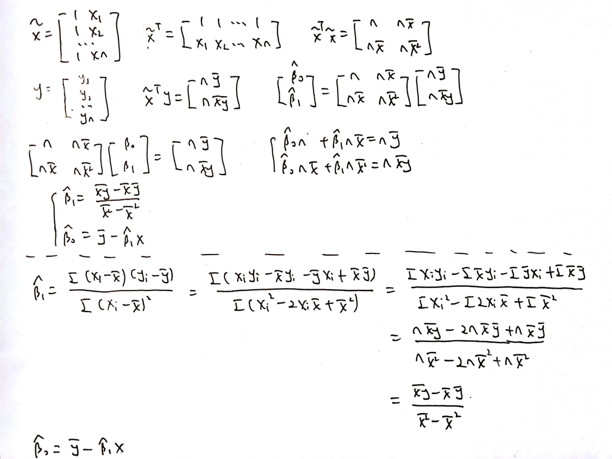

## Problem 4

#### (a)

```r
library(ISLR)
data("Auto")
summary(lm(mpg ~ cylinders, data = Auto))
```

```
##
## Call:
## lm(formula = mpg ~ cylinders, data = Auto)
##
## Residuals:
##      Min       1Q   Median       3Q      Max
## -14.2413  -3.1832  -0.6332   2.5491  17.9168
##
## Coefficients:
##             Estimate Std. Error t value Pr(>|t|)
## (Intercept)  42.9155     0.8349   51.40   <2e-16 ***
## cylinders    -3.5581     0.1457  -24.43   <2e-16 ***
## ---
## Signif. codes:  0 '***' 0.001 '**' 0.01 '*' 0.05 '.' 0.1 ' ' 1
##
## Residual standard error: 4.914 on 390 degrees of freedom
## Multiple R-squared:  0.6047, Adjusted R-squared:  0.6037
## F-statistic: 596.6 on 1 and 390 DF,  p-value: < 2.2e-16
```

```r
summary(lm(mpg ~ displacement, data = Auto))
```

```
##
## Call:
## lm(formula = mpg ~ displacement, data = Auto)
##
## Residuals:
##      Min       1Q   Median       3Q      Max
## -12.9170  -3.0243  -0.5021   2.3512  18.6128
##
## Coefficients:
##              Estimate Std. Error t value Pr(>|t|)
## (Intercept)  35.12064    0.49443   71.03   <2e-16 ***
## displacement -0.06005    0.00224  -26.81   <2e-16 ***
## ---
## Signif. codes:  0 '***' 0.001 '**' 0.01 '*' 0.05 '.' 0.1 ' ' 1
##
## Residual standard error: 4.635 on 390 degrees of freedom
## Multiple R-squared:  0.6482, Adjusted R-squared:  0.6473
## F-statistic: 718.7 on 1 and 390 DF,  p-value: < 2.2e-16
```

```r
summary(lm(mpg ~ horsepower, data = Auto))
```

```
##
## Call:
## lm(formula = mpg ~ horsepower, data = Auto)
##
## Residuals:
##      Min       1Q   Median       3Q      Max
## -13.5710  -3.2592  -0.3435   2.7630  16.9240
##
## Coefficients:
##              Estimate Std. Error t value Pr(>|t|)
## (Intercept) 39.935861   0.717499   55.66   <2e-16 ***
## horsepower  -0.157845   0.006446  -24.49   <2e-16 ***
## ---
## Signif. codes:  0 '***' 0.001 '**' 0.01 '*' 0.05 '.' 0.1 ' ' 1
##
## Residual standard error: 4.906 on 390 degrees of freedom
## Multiple R-squared:  0.6059, Adjusted R-squared:  0.6049
## F-statistic: 599.7 on 1 and 390 DF,  p-value: < 2.2e-16
```

```r
summary(lm(mpg ~ weight, data = Auto))
```

```
##
## Call:
## lm(formula = mpg ~ weight, data = Auto)
##
## Residuals:
##      Min       1Q   Median       3Q      Max
## -11.9736  -2.7556  -0.3358   2.1379  16.5194
##
## Coefficients:
##              Estimate Std. Error t value Pr(>|t|)
## (Intercept) 46.216524   0.798673   57.87   <2e-16 ***
## weight      -0.007647   0.000258  -29.64   <2e-16 ***
## ---
## Signif. codes:  0 '***' 0.001 '**' 0.01 '*' 0.05 '.' 0.1 ' ' 1
##
## Residual standard error: 4.333 on 390 degrees of freedom
## Multiple R-squared:  0.6926, Adjusted R-squared:  0.6918
## F-statistic: 878.8 on 1 and 390 DF,  p-value: < 2.2e-16
```

```r
summary(lm(mpg ~ acceleration, data = Auto))
```

```
##
## Call:
## lm(formula = mpg ~ acceleration, data = Auto)
##
## Residuals:
##     Min      1Q  Median      3Q     Max
## -17.989  -5.616  -1.199   4.801  23.239
##
## Coefficients:
##              Estimate Std. Error t value Pr(>|t|)
## (Intercept)    4.8332     2.0485   2.359   0.0188 *
## acceleration   1.1976     0.1298   9.228   <2e-16 ***
## ---
## Signif. codes:  0 '***' 0.001 '**' 0.01 '*' 0.05 '.' 0.1 ' ' 1
##
## Residual standard error: 7.08 on 390 degrees of freedom
## Multiple R-squared:  0.1792, Adjusted R-squared:  0.1771
## F-statistic: 85.15 on 1 and 390 DF,  p-value: < 2.2e-16
```

```r
summary(lm(mpg ~ as.factor(year), data = Auto))
```

```
##
## Call:
## lm(formula = mpg ~ as.factor(year), data = Auto)
##
## Residuals:
##     Min      1Q  Median      3Q     Max
## -14.704  -4.728  -1.000   4.286  19.039
##
## Coefficients:
##                   Estimate Std. Error t value Pr(>|t|)
## (Intercept)        17.6897     1.1117  15.913  < 2e-16 ***
## as.factor(year)71   3.4215     1.6010   2.137 0.033230 *
## as.factor(year)72   1.0246     1.5861   0.646 0.518668
## as.factor(year)73  -0.5897     1.4601  -0.404 0.686545
## as.factor(year)74   5.0796     1.6168   3.142 0.001812 **
## as.factor(year)75   2.5770     1.5590   1.653 0.099156 .
## as.factor(year)76   3.8839     1.5132   2.567 0.010653 *
## as.factor(year)77   5.6853     1.5861   3.584 0.000382 ***
## as.factor(year)78   6.3715     1.4938   4.265 2.52e-05 ***
## as.factor(year)79   7.4034     1.5721   4.709 3.50e-06 ***
## as.factor(year)80  16.1140     1.6010  10.065  < 2e-16 ***
## as.factor(year)81  12.4961     1.5861   7.878 3.54e-14 ***
## as.factor(year)82  14.3103     1.5590   9.179  < 2e-16 ***
## ---
## Signif. codes:  0 '***' 0.001 '**' 0.01 '*' 0.05 '.' 0.1 ' ' 1
##
## Residual standard error: 5.987 on 379 degrees of freedom
## Multiple R-squared:  0.4298, Adjusted R-squared:  0.4117
## F-statistic:  23.8 on 12 and 379 DF,  p-value: < 2.2e-16
```

```r
summary(lm(mpg ~ as.factor(origin), data = Auto))
```

```
##
## Call:
## lm(formula = mpg ~ as.factor(origin), data = Auto)
##
## Residuals:
##     Min      1Q  Median      3Q     Max
## -12.451  -5.034  -1.034   3.649  18.966
##
## Coefficients:
##                    Estimate Std. Error t value Pr(>|t|)
## (Intercept)         20.0335     0.4086  49.025   <2e-16 ***
## as.factor(origin)2   7.5695     0.8767   8.634   <2e-16 ***
## as.factor(origin)3  10.4172     0.8276  12.588   <2e-16 ***
## ---
## Signif. codes:  0 '***' 0.001 '**' 0.01 '*' 0.05 '.' 0.1 ' ' 1
##
## Residual standard error: 6.396 on 389 degrees of freedom
## Multiple R-squared:  0.3318, Adjusted R-squared:  0.3284
## F-statistic:  96.6 on 2 and 389 DF,  p-value: < 2.2e-16
```

1. There is a relationship between all the predictors and response because the p-value for all predictors are very small.
2. The weight predictor has a statistically significant relationship to the response because the R-squared of this model is the biggest among all predictors models.
3. The first coefficient means that the miles per gallon will be 17.6897 when the year is 70, and the coefficient below the first one is unit the miles per gallon will change according to the year(for example: if the year is 71, the miles per gallon will increase by 3.4215 and if the year is 72, the miles per gallon will increase by 1.0246…)

#### (b)

```r
summary(lm(mpg ~ horsepower, data = Auto))
```

```
##
## Call:
## lm(formula = mpg ~ horsepower, data = Auto)
##
## Residuals:
##      Min       1Q   Median       3Q      Max
## -13.5710  -3.2592  -0.3435   2.7630  16.9240
##
## Coefficients:
##              Estimate Std. Error t value Pr(>|t|)
## (Intercept) 39.935861   0.717499   55.66   <2e-16 ***
## horsepower  -0.157845   0.006446  -24.49   <2e-16 ***
## ---
## Signif. codes:  0 '***' 0.001 '**' 0.01 '*' 0.05 '.' 0.1 ' ' 1
##
## Residual standard error: 4.906 on 390 degrees of freedom
## Multiple R-squared:  0.6059, Adjusted R-squared:  0.6049
## F-statistic: 599.7 on 1 and 390 DF,  p-value: < 2.2e-16
```

```r
summary(lm(mpg ~ horsepower + I(horsepower ^ 2), data = Auto))
```

```
##
## Call:
## lm(formula = mpg ~ horsepower + I(horsepower^2), data = Auto)
##
## Residuals:
##      Min       1Q   Median       3Q      Max
## -14.7135  -2.5943  -0.0859   2.2868  15.8961
##
## Coefficients:
##                   Estimate Std. Error t value Pr(>|t|)
## (Intercept)     56.9000997  1.8004268   31.60   <2e-16 ***
## horsepower      -0.4661896  0.0311246  -14.98   <2e-16 ***
## I(horsepower^2)  0.0012305  0.0001221   10.08   <2e-16 ***
## ---
## Signif. codes:  0 '***' 0.001 '**' 0.01 '*' 0.05 '.' 0.1 ' ' 1
##
## Residual standard error: 4.374 on 389 degrees of freedom
## Multiple R-squared:  0.6876, Adjusted R-squared:  0.686
## F-statistic:   428 on 2 and 389 DF,  p-value: < 2.2e-16
```

```r
summary(lm(mpg ~ horsepower + I(horsepower ^ 2) + I(horsepower ^ 3), data = Auto))
```

```
##
## Call:
## lm(formula = mpg ~ horsepower + I(horsepower^2) + I(horsepower^3),
##     data = Auto)
##
## Residuals:
##      Min       1Q   Median       3Q      Max
## -14.7039  -2.4491  -0.1519   2.2035  15.8159
##
## Coefficients:
##                   Estimate Std. Error t value Pr(>|t|)
## (Intercept)      6.068e+01  4.563e+00  13.298  < 2e-16 ***
## horsepower      -5.689e-01  1.179e-01  -4.824 2.03e-06 ***
## I(horsepower^2)  2.079e-03  9.479e-04   2.193   0.0289 *
## I(horsepower^3) -2.147e-06  2.378e-06  -0.903   0.3673
## ---
## Signif. codes:  0 '***' 0.001 '**' 0.01 '*' 0.05 '.' 0.1 ' ' 1
##
## Residual standard error: 4.375 on 388 degrees of freedom
## Multiple R-squared:  0.6882, Adjusted R-squared:  0.6858
## F-statistic: 285.5 on 3 and 388 DF,  p-value: < 2.2e-16
```

The $R^2$ of the second model increase significantly while the $R^2$ of the third model increase slightly. Thus the second model is better because it can fit the model better and not overfitting.

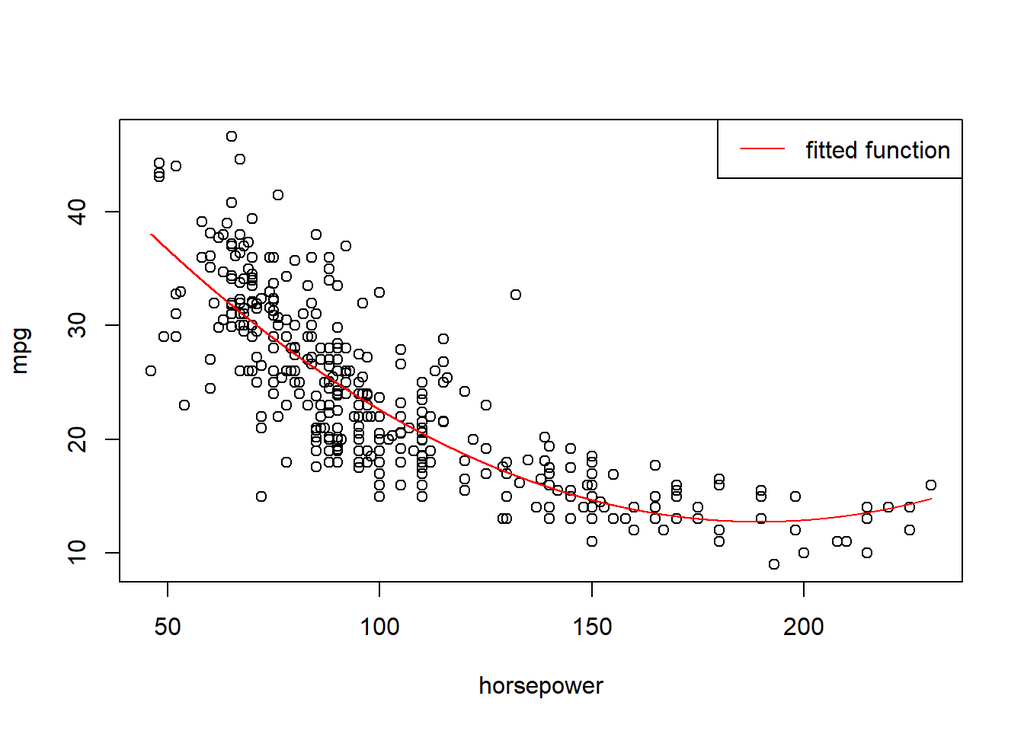

```r
lm.1 = lm(mpg ~ horsepower + I(horsepower ^ 2), data = Auto)
plot(Auto$horsepower, Auto$mpg, xlab = "horsepower", ylab = "mpg")
x = seq(min(Auto$horsepower), max(Auto$horsepower), 0.01)
y.fit = lm.1$coeff[1] + lm.1$coeff[2] * x + lm.1$coeff[3] * x ^ 2
points(x, y.fit, col = "red", type = "l")
legend('topright','fitted function', col = "red", lty = 1)
```

#### (c)

```r
summary(lm(mpg ~ horsepower + as.factor(origin) + horsepower : as.factor(origin), data = Auto))
```

```
##
## Call:
## lm(formula = mpg ~ horsepower + as.factor(origin) + horsepower:as.factor(origin),
##     data = Auto)
##
## Residuals:
##      Min       1Q   Median       3Q      Max
## -10.7415  -2.9547  -0.6389   2.3978  14.2495
##
## Coefficients:
##                                Estimate Std. Error t value Pr(>|t|)
## (Intercept)                   34.476496   0.890665  38.709  < 2e-16 ***
## horsepower                    -0.121320   0.007095 -17.099  < 2e-16 ***
## as.factor(origin)2            10.997230   2.396209   4.589 6.02e-06 ***
## as.factor(origin)3            14.339718   2.464293   5.819 1.24e-08 ***
## horsepower:as.factor(origin)2 -0.100515   0.027723  -3.626 0.000327 ***
## horsepower:as.factor(origin)3 -0.108723   0.028980  -3.752 0.000203 ***
## ---
## Signif. codes:  0 '***' 0.001 '**' 0.01 '*' 0.05 '.' 0.1 ' ' 1
##
## Residual standard error: 4.422 on 386 degrees of freedom
## Multiple R-squared:  0.6831, Adjusted R-squared:  0.679
## F-statistic: 166.4 on 5 and 386 DF,  p-value: < 2.2e-16
```

The miles per gallon will be 34.476496 when horsepower is zero and origin is American.

For American origin, the miles per gallon will change by -0.121320 with 1 unit change of horsepower.

For European origin, the miles per gallon will change by (-0.121320-0.100515) with 1 unit change of horsepower.

For Japanese origin, the miles per gallon will change by (-0.121320-0.108723) with 1 unit change of horsepower.

If the origin is America, the miles per gallon will not change.

If the origin is European, the miles per gallon will change by 10.997230 - 0.100515 * horsepower.

If the origin is Japanese, the miles per gallon will change by 14.339718 - 0.108723 * horsepower.

## Problem 5

#### (a)

balance = $\beta_0$ + $\beta_1*$income + $\beta_2*$graduate + $\beta_3*$undergraduate

If the person is a graduate student, the balance will change by $\beta_2$.

If the person is an undergraduate student, the balance will change by $\beta_3$.

If the person is not a student, the balance will not change.

balance change by $\beta_1$ with 1 unit change of income.

balance is $\beta_0$ if the income is zero and the person is not a student.

#### (b)

balance = $\beta_0$ + $\beta_1*$income + $\beta_2*$not student + $\beta_3*$graduate

If the person is a graduate student, the balance will change by $\beta_3$.

If the person is an undergraduate student, the balance will not change.

If the person is not a student, the balance will change by $\beta_2$.

balance change by $\beta_1$ with 1 unit change of income.

balance is $\beta_0$ if the income is zero and the person is an undergraduate student.

#### (c)

balance = $\beta_0$ + $\beta_1*$income + $\beta_2*$graduate + $\beta_3*$undergraduate + $\beta_4*$income $*$ graduate + $\beta_5*$income $*$ undergraduate

For graduate student, the balance change by $\beta_1+\beta_4$ with 1 unit change of income.

For undergraduate student, the balance change by $\beta_1+\beta_5$ with 1 unit change of income.

For not student, the balance change by $\beta_1$ with 1 unit change of income.

If the person is a graduate student, the balance will change by $\beta_2$ + $\beta_4*$income.

If the person is an undergraduate student, the balance will change by $\beta_3$ + $\beta_5*$income.

If the person is not a student, the balance will not change.

balance is $\beta_0$ if the income is zero and the person is not a student.

#### (d)

balance = $\beta_0$ + $\beta_1*$income + $\beta_2*$not student + $\beta_3*$graduate + $\beta_4*$income $*$ not student + $\beta_5*$income $*$ graduate

For graduate student, the balance change by $\beta_1+\beta_5$ with 1 unit change of income.

For undergraduate student, the balance change by $\beta_1$ with 1 unit change of income.

For not student, the balance change by $\beta_1+\beta_4$ with 1 unit change of income.

If the person is a graduate student, the balance will change by $\beta_3$ + $\beta_5*$income.

If the person is an undergraduate student, the balance will not change.

If the person is not a student, the balance will change by $\beta_2$ + $\beta_4*$income.

#### (e)

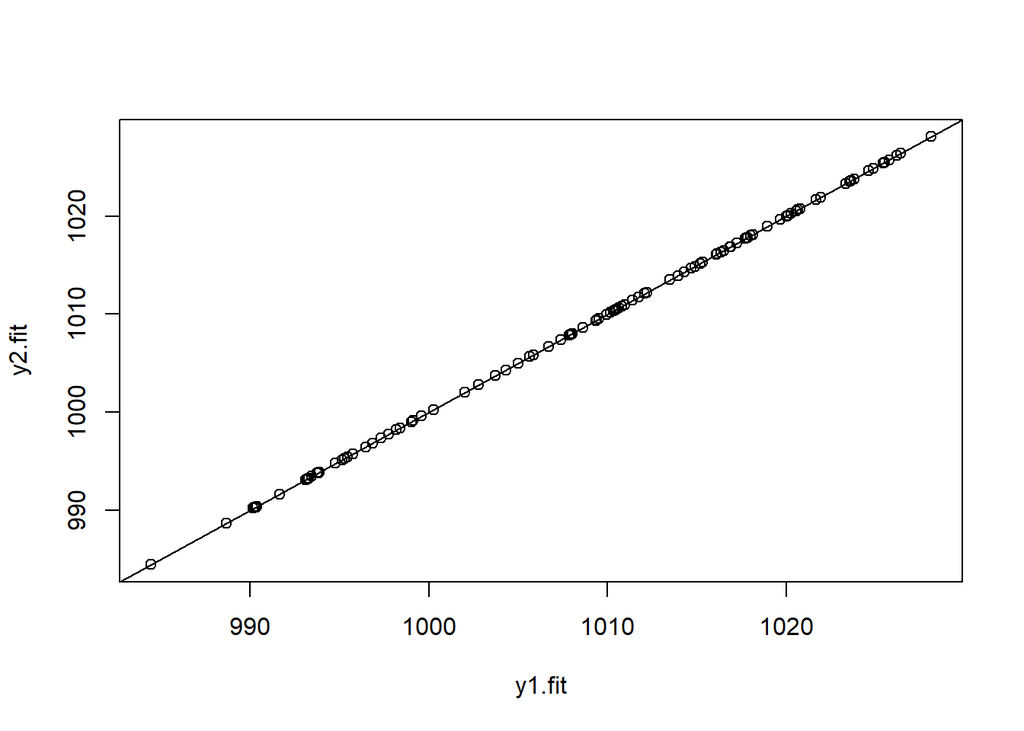

```r
set.seed(123)
balance = rnorm(100, 1000, 100)
income = rnorm(100, 30000, 500)
student = numeric(100)
for(i in 1:100){
  student[i] = sample(c("graduate", "undergraduate", "not student"), size = 1)
}
dummy1 = numeric(100)
dummy2 = numeric(100)
for(i in 1:100) {
  if (student[i] == "graduate") {
    dummy1[i] = 1
  }
  if (student[i] == "undergraduate") {
    dummy2[i] = 1
  }
}
lm.1 = lm(balance ~ income + dummy1 + dummy2)
y1.fit = lm.1$coeff[1] + income * lm.1$coeff[2] + dummy1 * lm.1$coeff[3] + dummy2 * lm.1$coeff[4]
lm.3 = lm(balance ~ income + dummy1 + dummy2 + income : dummy1 + income : dummy2)
y3.fit = lm.3$coeff[1] + income * lm.3$coeff[2] + dummy1 * lm.3$coeff[3] + dummy2 * lm.3$coeff[4] + income * dummy1 * lm.3$coeff[5] + income * dummy2 * lm.3$coeff[6]
dummy1 = numeric(100)
dummy2 = numeric(100)
for(i in 1:100) {
  if (student[i] == "graduate") {
    dummy2[i] = 1
  }
  if (student[i] == "not student") {
    dummy1[i] = 1
  }
}
lm.2 = lm(balance ~ income + dummy1 + dummy2)
y2.fit = lm.2$coeff[1] + income * lm.2$coeff[2] + dummy1 * lm.2$coeff[3] + dummy2 * lm.2$coeff[4]
lm.4 = lm(balance ~ income + dummy1 + dummy2 + income : dummy1 + income : dummy2)
y4.fit = lm.4$coeff[1] + income * lm.4$coeff[2] + dummy1 * lm.4$coeff[3] + dummy2 * lm.4$coeff[4] + income * dummy1 * lm.4$coeff[5] + income * dummy2 * lm.4$coeff[6]
plot(y1.fit, y2.fit)
abline(0, 1)
```

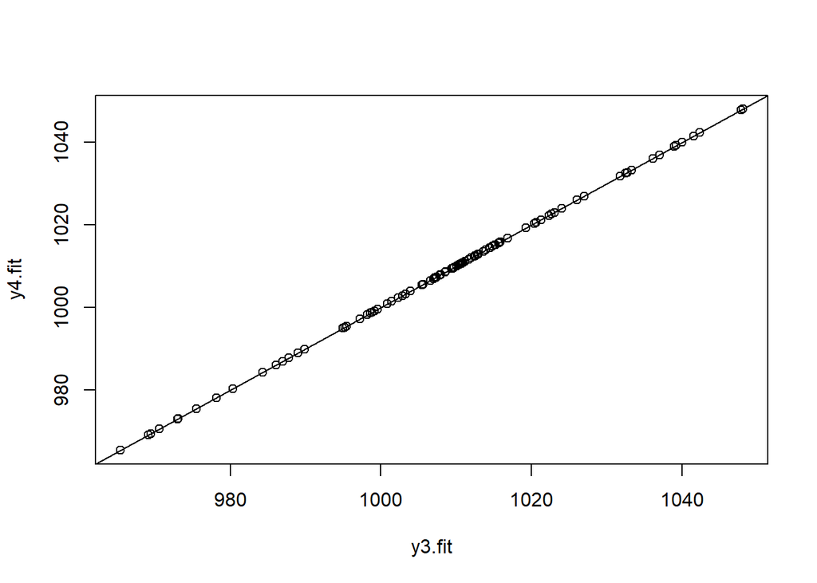

```r
plot(y3.fit, y4.fit)
abline(0, 1)
```

The plot shows that the y1.fit and y2.fit are equal, y3.fit and y4.fit are equal, which means that the fitted values (predictions) from the models in do not depend on the coding of the dummy variables.

## Problem 6

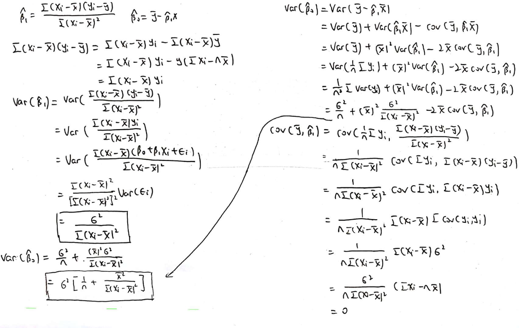